# RevisionCompleta

### 3.2.6 De PAY_0

En esta sección se cruza `PAY_0` (estado de pago del cliente en septiembre de 2005, convertida a factor) contra las mismas variables numéricas, para observar si el estado de pago más reciente se relaciona con el monto de crédito, la edad, los montos de estado de cuenta y los montos pagados.

Se cruza `LIMIT_BAL` contra `PAY_0`, para comparar el monto de crédito otorgado según el estado de pago de septiembre de 2005.

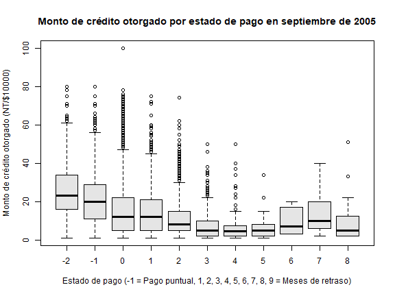

```r
boxplot(LIMIT_BAL/10000 ~ PAY_0, data = datos_credit_visu,
        main = "Monto de crédito otorgado por estado de pago en septiembre de 2005",
        xlab = "Estado de pago (-1 = Pago puntual, 1, 2, 3, 4, 5, 6, 7, 8, 9 = Meses de retraso)", ylab = "Monto de crédito otorgado (NT/$10000)",
        col = "grey90")
```

Hay un descenso claro y monótono de la caja a medida que aumenta el retraso, desde las categorías sin mora hasta los retrasos intermedios. En las categorías de retraso alto el patrón se vuelve errático y las cajas cambian de forma sin orden posiblemente por la falta de observaciones. La lectura confiable llega hasta los primeros meses de retraso.

Se cruza `AGE` contra `PAY_0`, para observar si la edad se relaciona con el estado de pago de septiembre de 2005.

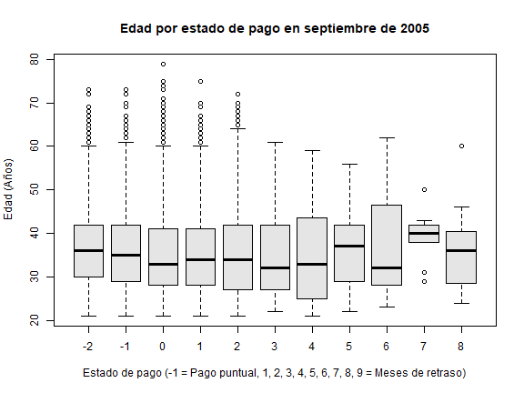

```r
boxplot(AGE ~ PAY_0, data = datos_credit_visu,
        main = "Edad por estado de pago en septiembre de 2005",
        xlab = "Estado de pago (-1 = Pago puntual, 1, 2, 3, 4, 5, 6, 7, 8, 9 = Meses de retraso)", ylab = "Edad (Años)",
        col = "grey90")
```

No hay un patrón visible. Las cajas de las categorías pobladas son casi idénticas; las de retraso alto oscilan sin dirección, otra vez por tamaño de grupo.

Se cruzan `BILL_AMT1` a `BILL_AMT6` contra `PAY_0`, generando un boxplot por mes para comparar el monto del estado de cuenta según el estado de pago de septiembre de 2005.

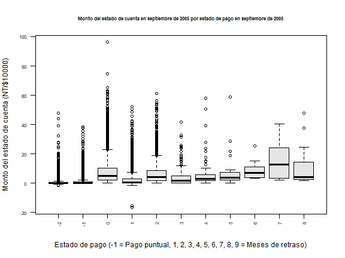

```r
boxplot(BILL_AMT1/10000 ~ PAY_0, data = datos_credit_visu,
        main = "Monto del estado de cuenta en septiembre de 2005 por estado de pago en septiembre de 2005",
        las = 2,
        cex.axis = 0.7,
        cex.main = 0.7,
        xlab = "Estado de pago (-1 = Pago puntual, 1, 2, 3, 4, 5, 6, 7, 8, 9 = Meses de retraso)", ylab = "Monto del estado de cuenta (NT/$10000)",
        col = "grey90")
```

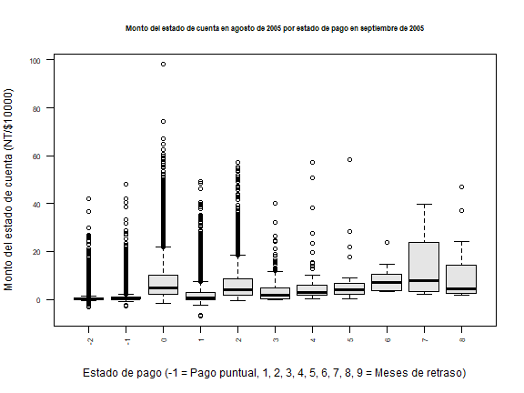

```r
boxplot(BILL_AMT2/10000 ~ PAY_0, data = datos_credit_visu,
        main = "Monto del estado de cuenta en agosto de 2005 por estado de pago en septiembre de 2005",
        las = 2,
        cex.axis = 0.7,
        cex.main = 0.7,
        xlab = "Estado de pago (-1 = Pago puntual, 1, 2, 3, 4, 5, 6, 7, 8, 9 = Meses de retraso)", ylab = "Monto del estado de cuenta (NT/$10000)",
        col = "grey90")
```

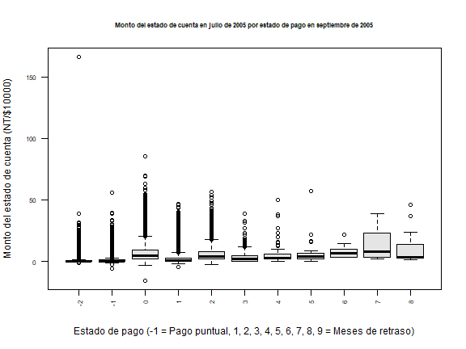

```r
boxplot(BILL_AMT3/10000 ~ PAY_0, data = datos_credit_visu,
        main = "Monto del estado de cuenta en julio de 2005 por estado de pago en septiembre de 2005",
        las = 2,
        cex.axis = 0.7,
        cex.main = 0.7,
        xlab = "Estado de pago (-1 = Pago puntual, 1, 2, 3, 4, 5, 6, 7, 8, 9 = Meses de retraso)", ylab = "Monto del estado de cuenta (NT/$10000)",
        col = "grey90")
```

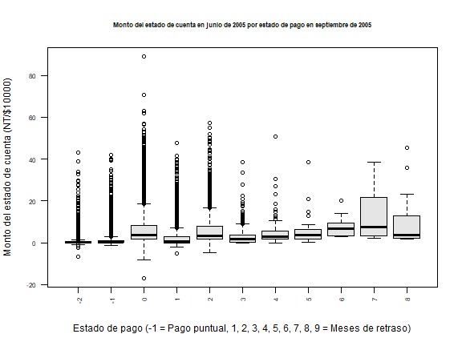

```r
boxplot(BILL_AMT4/10000 ~ PAY_0, data = datos_credit_visu,
        main = "Monto del estado de cuenta en junio de 2005 por estado de pago en septiembre de 2005",
        las = 2,
        cex.axis = 0.7,
        cex.main = 0.7,
        xlab = "Estado de pago (-1 = Pago puntual, 1, 2, 3, 4, 5, 6, 7, 8, 9 = Meses de retraso)", ylab = "Monto del estado de cuenta (NT/$10000)",
        col = "grey90")
```

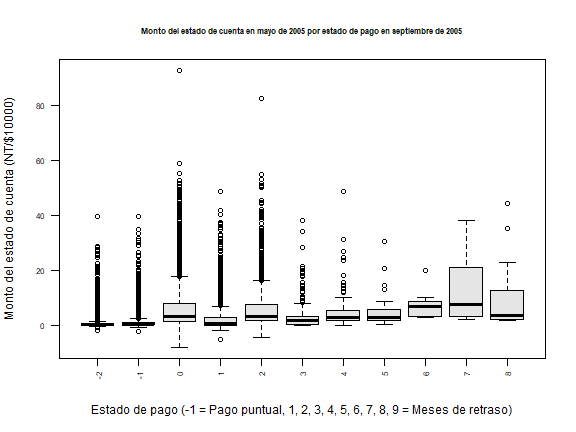

```r
boxplot(BILL_AMT5/10000 ~ PAY_0, data = datos_credit_visu,
        main = "Monto del estado de cuenta en mayo de 2005 por estado de pago en septiembre de 2005",
        las = 2,
        cex.axis = 0.7,
        cex.main = 0.7,
        xlab = "Estado de pago (-1 = Pago puntual, 1, 2, 3, 4, 5, 6, 7, 8, 9 = Meses de retraso)", ylab = "Monto del estado de cuenta (NT/$10000)",
        col = "grey90")
```

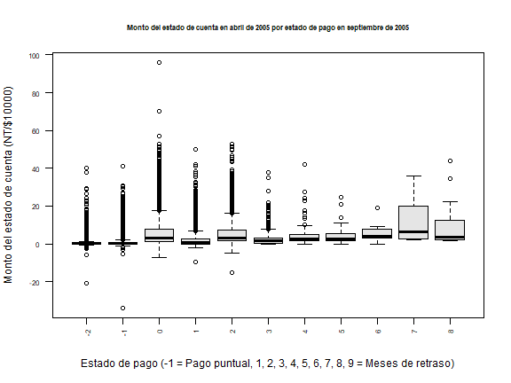

```r
boxplot(BILL_AMT6/10000 ~ PAY_0, data = datos_credit_visu,
        main = "Monto del estado de cuenta en abril de 2005 por estado de pago en septiembre de 2005",
        las = 2,
        cex.axis = 0.7,
        cex.main = 0.7,
        xlab = "Estado de pago (-1 = Pago puntual, 1, 2, 3, 4, 5, 6, 7, 8, 9 = Meses de retraso)", ylab = "Monto del estado de cuenta (NT/$10000)",
        col = "grey90")
```

Se cruzan `PAY_AMT1` a `PAY_AMT6` contra `PAY_0`, para comparar cuánto pagaron efectivamente los clientes según su estado de pago de septiembre de 2005, mes a mes.

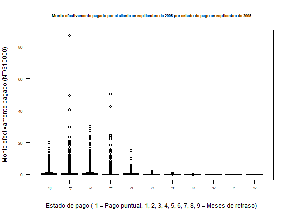

```r
boxplot(PAY_AMT1/10000 ~ PAY_0, data = datos_credit_visu,
        main = "Monto efectivamente pagado por el cliente en septiembre de 2005 por estado de pago en septiembre de 2005",
        las = 2,
        cex.axis = 0.7,
        cex.main = 0.7,
        xlab = "Estado de pago (-1 = Pago puntual, 1, 2, 3, 4, 5, 6, 7, 8, 9 = Meses de retraso)", ylab = "Monto efectivamente pagado (NT/$10000)",
        col = "grey90")
```

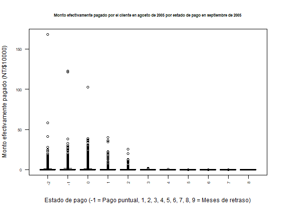

```r
boxplot(PAY_AMT2/10000 ~ PAY_0, data = datos_credit_visu,
        main = "Monto efectivamente pagado por el cliente en agosto de 2005 por estado de pago en septiembre de 2005",
        las = 2,
        cex.axis = 0.7,
        cex.main = 0.7,
        xlab = "Estado de pago (-1 = Pago puntual, 1, 2, 3, 4, 5, 6, 7, 8, 9 = Meses de retraso)", ylab = "Monto efectivamente pagado (NT/$10000)",
        col = "grey90")
```

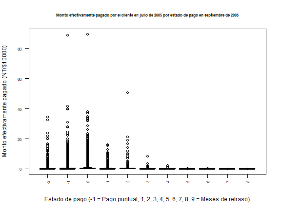

```r
boxplot(PAY_AMT3/10000 ~ PAY_0, data = datos_credit_visu,
        main = "Monto efectivamente pagado por el cliente en julio de 2005 por estado de pago en septiembre de 2005",
        las = 2,
        cex.axis = 0.7,
        cex.main = 0.7,
        xlab = "Estado de pago (-1 = Pago puntual, 1, 2, 3, 4, 5, 6, 7, 8, 9 = Meses de retraso)", ylab = "Monto efectivamente pagado (NT/$10000)",
        col = "grey90")
```

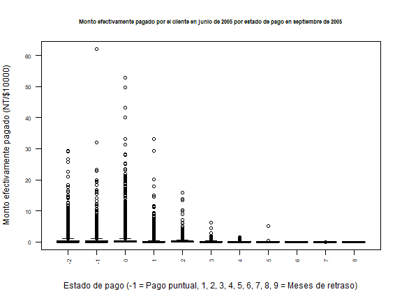

```r
boxplot(PAY_AMT4/10000 ~ PAY_0, data = datos_credit_visu,
        main = "Monto efectivamente pagado por el cliente en junio de 2005 por estado de pago en septiembre de 2005",
        las = 2,
        cex.axis = 0.7,
        cex.main = 0.7,
        xlab = "Estado de pago (-1 = Pago puntual, 1, 2, 3, 4, 5, 6, 7, 8, 9 = Meses de retraso)", ylab = "Monto efectivamente pagado (NT/$10000)",
        col = "grey90")
```

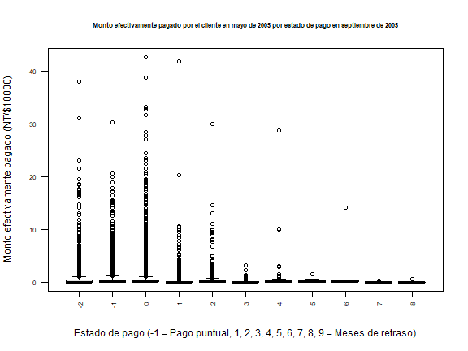

```r
boxplot(PAY_AMT5/10000 ~ PAY_0, data = datos_credit_visu,
        main = "Monto efectivamente pagado por el cliente en mayo de 2005 por estado de pago en septiembre de 2005",
        las = 2,
        cex.axis = 0.7,
        cex.main = 0.7,
        xlab = "Estado de pago (-1 = Pago puntual, 1, 2, 3, 4, 5, 6, 7, 8, 9 = Meses de retraso)", ylab = "Monto efectivamente pagado (NT/$10000)",
        col = "grey90")
```

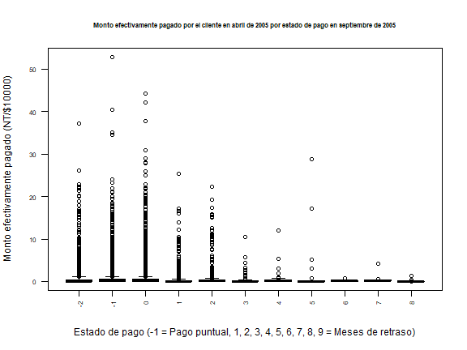

```r
boxplot(PAY_AMT6/10000 ~ PAY_0, data = datos_credit_visu,
        main = "Monto efectivamente pagado por el cliente en abril de 2005 por estado de pago en septiembre de 2005",
        las = 2,
        cex.axis = 0.7,
        cex.main = 0.7,
        xlab = "Estado de pago (-1 = Pago puntual, 1, 2, 3, 4, 5, 6, 7, 8, 9 = Meses de retraso)", ylab = "Monto efectivamente pagado (NT/$10000)",
        col = "grey90")
```

Las categorías -2, -1 y 0 concentran toda la masa de pagos, con colas largas y densas. A partir del primer mes de retraso las colas tienden a acortarse de forma abrupta, y desde los retrasos medios en adelante prácticamente desaparece cualquier abono.

### 3.2.7 De PAY_2

En esta sección se cruza `PAY_2` (estado de pago del cliente en agosto de 2005, convertida a factor) contra las mismas variables numéricas, siguiendo la misma lógica de la sección de `PAY_0`.

Se cruza `LIMIT_BAL` contra `PAY_2`, para comparar el monto de crédito otorgado según el estado de pago de agosto de 2005.

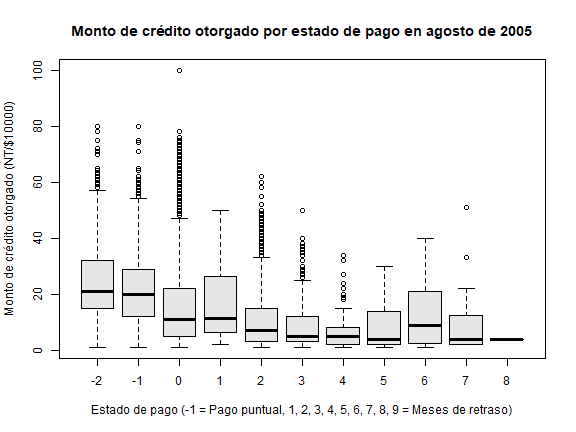

```r
boxplot(LIMIT_BAL/10000 ~ PAY_2, data = datos_credit_visu,
        main = "Monto de crédito otorgado por estado de pago en agosto de 2005",
        xlab = "Estado de pago (-1 = Pago puntual, 1, 2, 3, 4, 5, 6, 7, 8, 9 = Meses de retraso)", ylab = "Monto de crédito otorgado (NT/$10000)",
        col = "grey90")
```

Las categorías -2 y -1 reciben los cupos más altos. La 0 baja claramente, aunque conserva muchos clientes con cupos altos. A medida que aumenta el retraso, los cupos disminuyen. Esto sugiere que el banco asigna menos crédito a perfiles de mayor riesgo, o que quienes tienen cupos bajos se atrasan más. La categoría 1 y las de retraso alto (5 a 8) tienen muy pocos casos, así que sus cajas no son confiables

Se cruza `AGE` contra `PAY_2`, para observar si la edad se relaciona con el estado de pago de agosto de 2005.

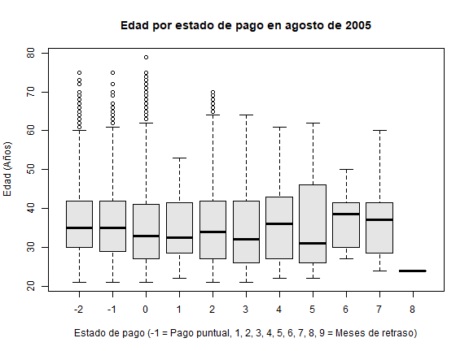

```r
boxplot(AGE ~ PAY_2, data = datos_credit_visu,
        main = "Edad por estado de pago en agosto de 2005",
        xlab = "Estado de pago (-1 = Pago puntual, 1, 2, 3, 4, 5, 6, 7, 8, 9 = Meses de retraso)", ylab = "Edad (Años)",
        col = "grey90")
```

Las medianas y las cajas son muy parecidas entre categorías, y las diferencias en los retrasos altos se explican por el bajo número de casos, por lo que no hay una relación visible.

Se cruzan `BILL_AMT1` a `BILL_AMT6` contra `PAY_2`, generando un boxplot por mes para comparar el monto del estado de cuenta según el estado de pago de agosto de 2005.

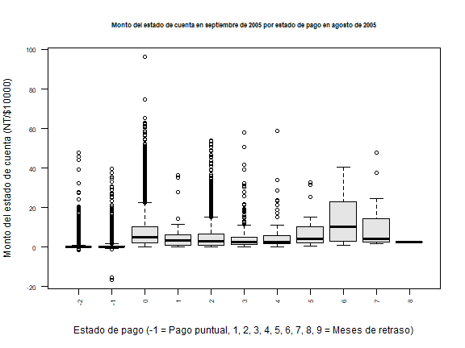

```r
boxplot(BILL_AMT1/10000 ~ PAY_2, data = datos_credit_visu,
        main = "Monto del estado de cuenta en septiembre de 2005 por estado de pago en agosto de 2005",
        las = 2,
        cex.axis = 0.7,
        cex.main = 0.7,
        xlab = "Estado de pago (-1 = Pago puntual, 1, 2, 3, 4, 5, 6, 7, 8, 9 = Meses de retraso)", ylab = "Monto del estado de cuenta (NT/$10000)",
        col = "grey90")
```

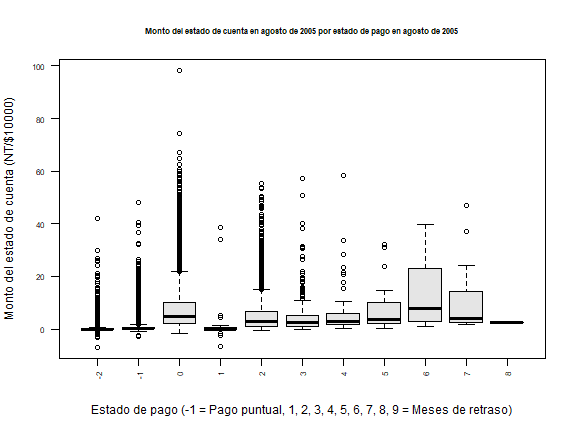

```r
boxplot(BILL_AMT2/10000 ~ PAY_2, data = datos_credit_visu,
        main = "Monto del estado de cuenta en agosto de 2005 por estado de pago en agosto de 2005",
        las = 2,
        cex.axis = 0.7,
        cex.main = 0.7,
        xlab = "Estado de pago (-1 = Pago puntual, 1, 2, 3, 4, 5, 6, 7, 8, 9 = Meses de retraso)", ylab = "Monto del estado de cuenta (NT/$10000)",
        col = "grey90")
```

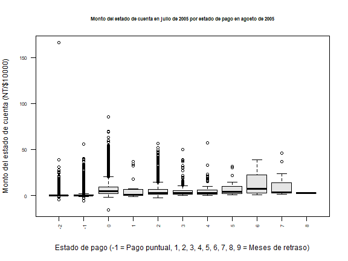

```r
boxplot(BILL_AMT3/10000 ~ PAY_2, data = datos_credit_visu,
        main = "Monto del estado de cuenta en julio de 2005 por estado de pago en agosto de 2005",
        las = 2,
        cex.axis = 0.7,
        cex.main = 0.7,
        xlab = "Estado de pago (-1 = Pago puntual, 1, 2, 3, 4, 5, 6, 7, 8, 9 = Meses de retraso)", ylab = "Monto del estado de cuenta (NT/$10000)",
        col = "grey90")
```

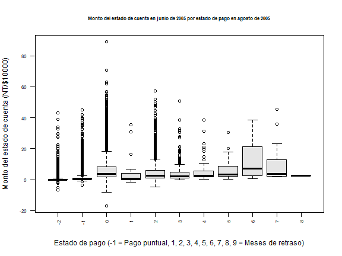

```r
boxplot(BILL_AMT4/10000 ~ PAY_2, data = datos_credit_visu,
        main = "Monto del estado de cuenta en junio de 2005 por estado de pago en agosto de 2005",
        las = 2,
        cex.axis = 0.7,
        cex.main = 0.7,
        xlab = "Estado de pago (-1 = Pago puntual, 1, 2, 3, 4, 5, 6, 7, 8, 9 = Meses de retraso)", ylab = "Monto del estado de cuenta (NT/$10000)",
        col = "grey90")
```

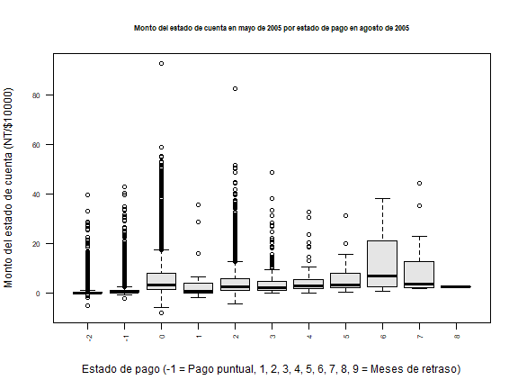

```r
boxplot(BILL_AMT5/10000 ~ PAY_2, data = datos_credit_visu,
        main = "Monto del estado de cuenta en mayo de 2005 por estado de pago en agosto de 2005",
        las = 2,
        cex.axis = 0.7,
        cex.main = 0.7,
        xlab = "Estado de pago (-1 = Pago puntual, 1, 2, 3, 4, 5, 6, 7, 8, 9 = Meses de retraso)", ylab = "Monto del estado de cuenta (NT/$10000)",
        col = "grey90")
```

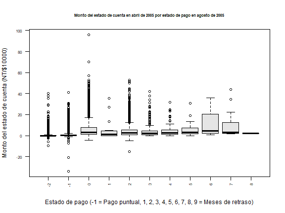

```r
boxplot(BILL_AMT6/10000 ~ PAY_2, data = datos_credit_visu,
        main = "Monto del estado de cuenta en abril de 2005 por estado de pago en agosto de 2005",
        las = 2,
        cex.axis = 0.7,
        cex.main = 0.7,
        xlab = "Estado de pago (-1 = Pago puntual, 1, 2, 3, 4, 5, 6, 7, 8, 9 = Meses de retraso)", ylab = "Monto del estado de cuenta (NT/$10000)",
        col = "grey90")
```

Se cruzan `PAY_AMT1` a `PAY_AMT6` contra `PAY_2`, para comparar cuánto pagaron efectivamente los clientes según su estado de pago de agosto de 2005, mes a mes.

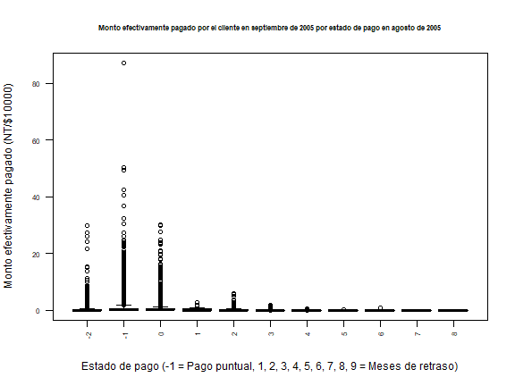

```r
boxplot(PAY_AMT1/10000 ~ PAY_2, data = datos_credit_visu,
        main = "Monto efectivamente pagado por el cliente en septiembre de 2005 por estado de pago en agosto de 2005",
        las = 2,
        cex.axis = 0.7,
        cex.main = 0.7,
        xlab = "Estado de pago (-1 = Pago puntual, 1, 2, 3, 4, 5, 6, 7, 8, 9 = Meses de retraso)", ylab = "Monto efectivamente pagado (NT/$10000)",
        col = "grey90")
```

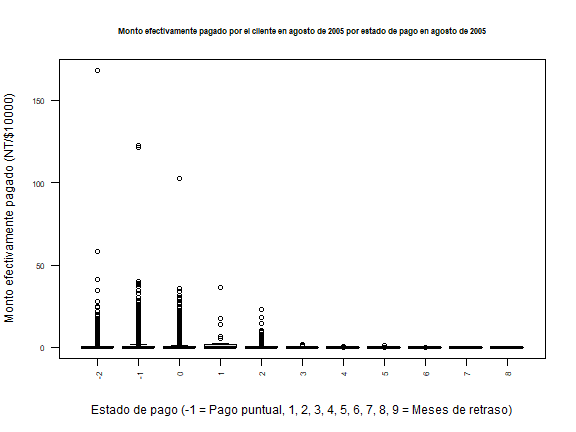

```r
boxplot(PAY_AMT2/10000 ~ PAY_2, data = datos_credit_visu,
        main = "Monto efectivamente pagado por el cliente en agosto de 2005 por estado de pago en agosto de 2005",
        las = 2,
        cex.axis = 0.7,
        cex.main = 0.7,
        xlab = "Estado de pago (-1 = Pago puntual, 1, 2, 3, 4, 5, 6, 7, 8, 9 = Meses de retraso)", ylab = "Monto efectivamente pagado (NT/$10000)",
        col = "grey90")
```

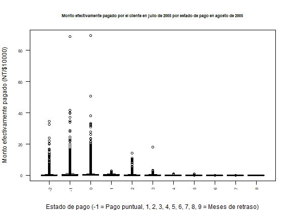

```r
boxplot(PAY_AMT3/10000 ~ PAY_2, data = datos_credit_visu,
        main = "Monto efectivamente pagado por el cliente en julio de 2005 por estado de pago en agosto de 2005",
        las = 2,
        cex.axis = 0.7,
        cex.main = 0.7,
        xlab = "Estado de pago (-1 = Pago puntual, 1, 2, 3, 4, 5, 6, 7, 8, 9 = Meses de retraso)", ylab = "Monto efectivamente pagado (NT/$10000)",
        col = "grey90")
```

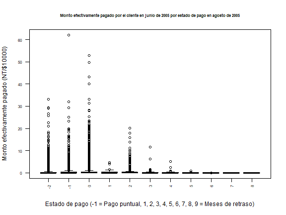

```r
boxplot(PAY_AMT4/10000 ~ PAY_2, data = datos_credit_visu,
        main = "Monto efectivamente pagado por el cliente en junio de 2005 por estado de pago en agosto de 2005",
        las = 2,
        cex.axis = 0.7,
        cex.main = 0.7,
        xlab = "Estado de pago (-1 = Pago puntual, 1, 2, 3, 4, 5, 6, 7, 8, 9 = Meses de retraso)", ylab = "Monto efectivamente pagado (NT/$10000)",
        col = "grey90")
```

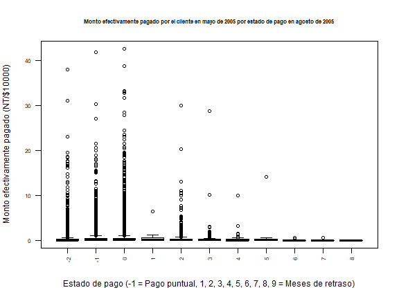

```r
boxplot(PAY_AMT5/10000 ~ PAY_2, data = datos_credit_visu,
        main = "Monto efectivamente pagado por el cliente en mayo de 2005 por estado de pago en agosto de 2005",
        las = 2,
        cex.axis = 0.7,
        cex.main = 0.7,
        xlab = "Estado de pago (-1 = Pago puntual, 1, 2, 3, 4, 5, 6, 7, 8, 9 = Meses de retraso)", ylab = "Monto efectivamente pagado (NT/$10000)",
        col = "grey90")
```

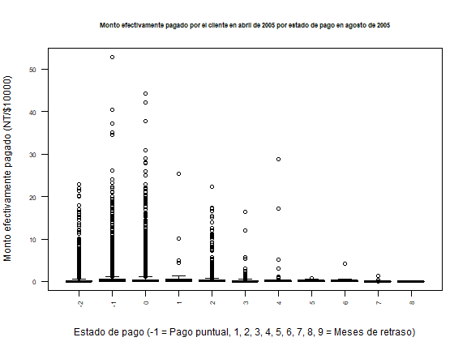

```r
boxplot(PAY_AMT6/10000 ~ PAY_2, data = datos_credit_visu,
        main = "Monto efectivamente pagado por el cliente en abril de 2005 por estado de pago en agosto de 2005",
        las = 2,
        cex.axis = 0.7,
        cex.main = 0.7,
        xlab = "Estado de pago (-1 = Pago puntual, 1, 2, 3, 4, 5, 6, 7, 8, 9 = Meses de retraso)", ylab = "Monto efectivamente pagado (NT/$10000)",
        col = "grey90")
```